# Reproducible Research: Peer Assessment 1

Sanjaya J Shetty

24/11/2020

# Loading Library

```r
library(dplyr)
library(ggplot2)
library(Hmisc) #Used to impute
```

## Loading and preprocessing of the dataset

### Loading the Data

```r
Data <- read.csv("activity.csv")
```

## What is mean total number of steps taken per day?

### 1. Calculate the total number of steps taken per day

```r
Total_Steps <- aggregate(steps ~date, Data, sum)
sum(Total_Steps$steps)
```

```
## [1] 570608
```

### 2. Make a histogram of the total number of steps taken each day

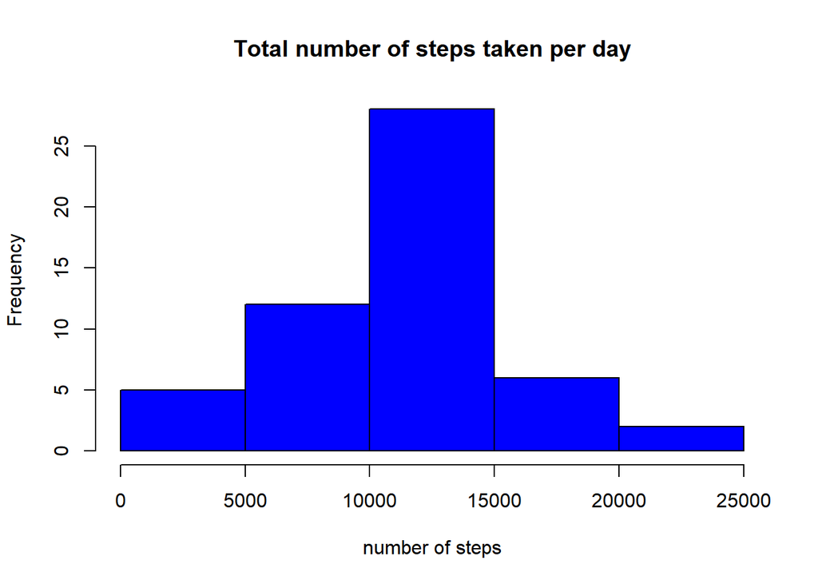

```r
hist(Total_Steps$steps,
    main =  "Total number of steps taken per day",
    col = "Blue",
    xlab = "number of steps",
    ylab = "Frequency")
```

### 3. Calculate and report the mean and median of the total number of steps taken per day

```r
Steps_mean <- mean(Total_Steps$steps, na.rm = T)
Steps_mean
```

```
## [1] 10766.19
```

```r
Steps_median <- median(Total_Steps$steps, na.rm = T)
Steps_median
```

```
## [1] 10765
```

### 4. What is the average daily activity pattern?

#### Make a time series plot of the 5-minute interval (x-axis) and the average number of steps taken, averaged across all days (y-axis)

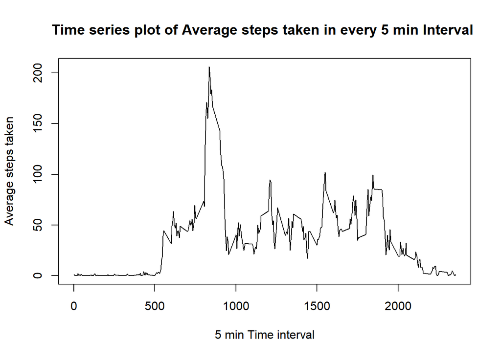

```r
FiveMin_int <-  aggregate(steps~interval, Data, mean, na.rm = T)

plot(FiveMin_int$interval,
     FiveMin_int$steps,
     type = "l",
     xlab = "5 min Time interval",
     ylab = "Average steps taken",
     main = "Time series plot of Average steps taken in every 5 min Interval ")
```

### 5. Which 5-minute interval, on average across all the days in the dataset, contains the maximum number of steps?

```r
Max_Step <- FiveMin_int$interval[which.max(FiveMin_int$steps)]
Max_Step
```

```
## [1] 835
```

## Imputing missing values

### 6. Calculate and report the total number of missing values in the dataset (i.e. the total number of rows NAs)

```r
Num_Missing_Values <-length(which(is.na(Data$steps)))
Num_Missing_Values
```

```
## [1] 2304
```

- Total Number of missing values : 2304

## Devise a strategy for filling in all of the missing values in the dataset. The strategy does not need to be sophisticated. For example, you could use the mean/median for that day, or the mean for that 5-minute interval, etc

### 7. Create a new dataset that is equal to the original dataset but with the missing data filled in.

```r
DataImputed <- Data
DataImputed$steps <- impute(Data$steps, mean)
DataImputed
```

[output not shown]

# 8. Make a histogram of the total number of steps taken each day and Calculate and report the mean and median total number of steps taken per day. Do these values differ from the estimates from the first part of the assignment? What is the impact of imputing missing data on the estimates of the total daily number of steps?

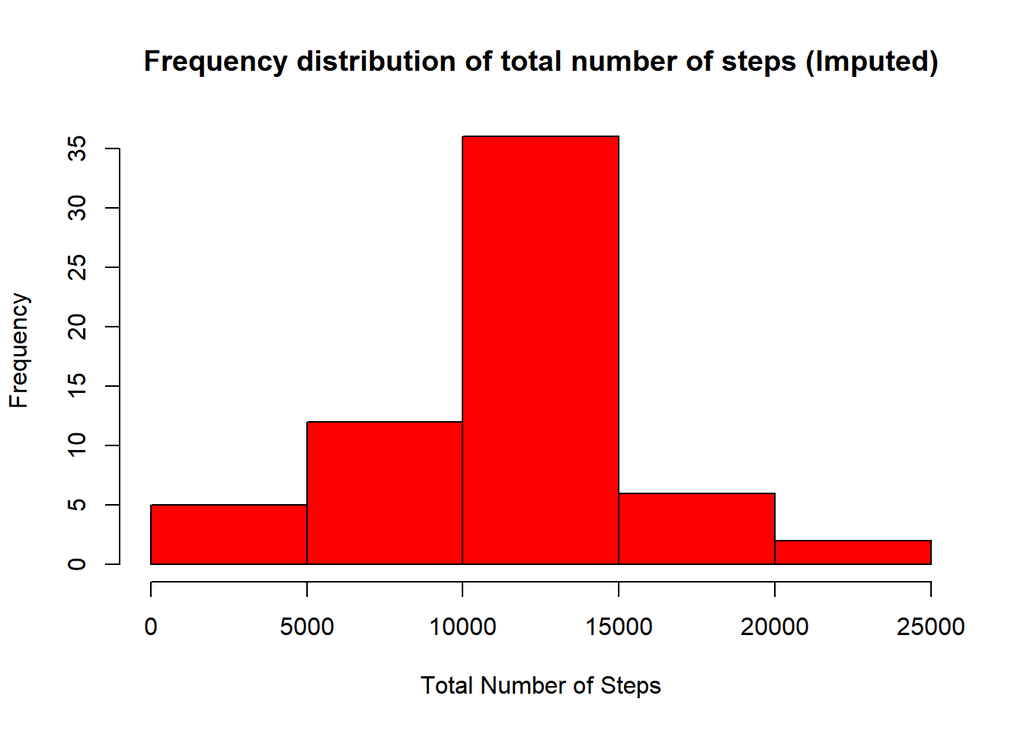

```r
Total_Steps_2 <- aggregate(steps~date, DataImputed, sum)

hist(Total_Steps_2$steps,
     xlab = "Total Number of Steps",
     main = "Frequency distribution of total number of steps (Imputed)",
     col = "red")
```

## Mean of the Imputed Data

```r
Mean_DataImputed <-  mean(Total_Steps_2$steps)
Mean_DataImputed
```

```
## [1] 10766.19
```

```r
Median_DataImputed <- median(Total_Steps_2$steps)
Median_DataImputed
```

```
## [1] 10766.19
```

## Are there differences in activity patterns between weekdays and weekends?

### 9. Create a new factor variable in the dataset with two levels - “weekday” and “weekend” indicating whether a given date is a weekday or weekend day.

```r
DataImputed$date <-  as.Date(DataImputed$date)
DataImputed$Days <-  weekdays(DataImputed$date)

DataImputed$Week_Type <- ifelse(DataImputed$Days == "Saturday" | DataImputed$Days == "Sunday", "Weekend", "Weekday")

Total_Steps_3 <- aggregate(steps~interval+Week_Type, DataImputed, mean)
```

### 10. Make a panel plot containing a time series plot of the 5-minute interval (x-axis) and the average number of steps taken, averaged across all weekday days or weekend days (y-axis).

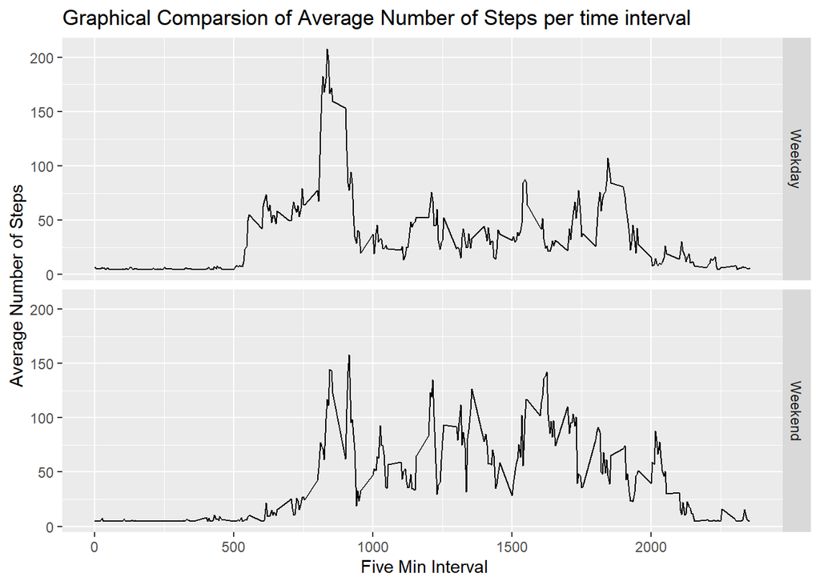

```r
ggplot(Total_Steps_3, aes(x = interval, y = steps))+
      geom_line()+
      facet_grid(Week_Type~.)+
      xlab(" Five Min Interval")+
      ylab("Average Number of Steps")+
      ggtitle("Graphical Comparsion of Average Number of Steps per time interval ")
```